# The South Dakota Retirement System (SDRS): Modeling approach and simulation results

# 1 **Overview of key risk-sharing features**

The South Dakota Retirement System (SDRS) adopted a contingent COLA policy in response to the Great Recession. In 2017, South Dakota approved changes which, along with other funding arrangements of SDRS, aim to achieve budgetary certainty for the sponsoring governments, funding sufficiency for the plan, and retirement adequacy for retirees.

The current SDRS policy includes the following fundamental features:

- Fixed, statutory member and employer contribution rates. Currently, both employee and employer contributions of SDRS are fixed at about 6 percent of payroll.
- Flexible benefits that change based on economic conditions and the SDRS funded status. A contingent COLA is the most important component of the flexible benefit arrangement.
- If COLA adjustments cannot achieve full funding while keeping employer contributions in a stable target range, the policy requires corrective actions. Those actions are not fully spelled out, and might include benefit reductions, contribution increases by employers or employees, or other actions by the legislature or the retirement system. While this feature does not require specific actions, it is a formal statement that action must be taken.

The SDRS policy seeks to keep employer contributions stable and stay fully funded by adjusting the COLA whenever possible. However, the COLA cannot be reduced below 0.5 percent or raised above 3.5 percent. It will not always be possible to achieve these goals, and the policy therefore requires a corrective action plan without defining what that plan must do.

In this policy, plan retirees bear almost all risk through COLAs that are linked to the plan funding status, unless the underfunding gap becomes so severe that corrective action is triggered and requires the employer or active plan members to share the risk.

# 2 **Summary of modeling approach**

## 2.1 Policy scenarios

To examine the impact of the SDRS risk-sharing features on plan costs, funded status, and member benefit, we run the simulation under the following three policy scenarios.

1. **SDRS policy, cost of corrective action borne by employer**
   - It is assumed that additional contributions are required when corrective action is triggered.
   - The additional contributions are solely made by employer
2. **SDRS policy, cost of corrective action shared between employer and employees**
   - It is assumed that additional contributions are required when corrective action is triggered.
   - The additional contributions are evenly split between employer and employees
3. **A DB plan with the same benefit rules as SDRS but without the SDRS risk-sharing policies**

Additional variants will be examined in future analysis.

## 2.2 Investment return scenarios

1. Stochastic: 6.75% expected mean return, 12% standard deviation. This is just for purposes of initial analysis. Will be replaced by scenarios and capital market assumptions provided by Pew.

## 2.3 Model assumptions and Simplifications

- There are two tiers in SDRS: Foundation (pre-2017) and Generational (post-2017). Currently the benefit rules for Foundation members are applied to all members. We will model the two tiers separately in later versions.
- Benefit rules for Foundation members:
  - Normal retirement age: 65
  - Benefit factor: 1.7% for service before 2008 and 1.55% for service after 2008.
  - Range of COLA: 0.5% to 3.5%
- Key valuation methods and assumptions:
  - Discount rate: 6.5%
  - Cost method: EAN
  - Baseline COLA: 2.25%
  - Asset smoothing: No (market value)
  - Amortization of UAAL in policy scenario 3: 20-year level-percent closed amortization

# 3 **Simulation results**

## 3.1 Summary of investment return scenarios

Please note that investment return percentile points won’t correspond exactly with percentile points for employer contributions or other concepts. For example, the 10th percentile for the long-run investment return won’t occur at the same simulation as the 10th percentile for the PV of employer contributions.

Distribution of 30-year compound annual returns

2021-2050; percentiles of 1,000 runs

| 90th | 75th | 50th | 25th | 10th |
| --- | --- | --- | --- | --- |
| 9.3% | 7.8% | 6.5% | 5.0% | 3.8% |

## 3.2 Analysis of contributions

### 3.2.2 Distribution of long-term costs (Cost components add up)

Making the cost components add up to the PV of total contribution with terminal UAAL:

Note that the fixed statutory contribution rates tend to create very large surpluses under the current assumption on corrective action (making additional contributions when COLA adjustment cannot maintain full funding): contribution rates cannot be reduced when there are investment gains, and additional contributions are required when there are investment losses. We will further investigate this and will implement the corrective action of increasing benefits when surpluses are large.

(Click tabs below to show tables)

#### PV of total contribution with terminal UAAL

Distribution of 30-year present value of total contribution plus terminal UAAL

| Policy | 90th | 75th | 50th | 25th | 10th |
| --- | --- | --- | --- | --- | --- |
| SDRS COLA; CA cost by ER | 258.6 | 191.2 | 100.0 | −7.1 | −201.9 |
| SDRS COLA; CA cost shared 50/50 | 258.6 | 191.2 | 100.0 | −7.1 | −201.9 |
| No SDRS COLA; same benefit rule | 285.8 | 213.1 | 115.3 | 2.3 | −168.7 |

#### PV of employer contribution

Distribution of 30-year present value of ERC

| Policy | 90th | 75th | 50th | 25th | 10th |
| --- | --- | --- | --- | --- | --- |
| SDRS COLA; CA cost by ER | 195.1 | 138.4 | 137.8 | 66.0 | 77.1 |
| SDRS COLA; CA cost shared 50/50 | 130.6 | 102.2 | 101.9 | 66.0 | 71.6 |
| No SDRS COLA; same benefit rule | 163.7 | 132.3 | 51.1 | 11.3 | 36.1 |

#### PV of employee contribution

Distribution of 30-year present value of EEC

| Policy | 90th | 75th | 50th | 25th | 10th |
| --- | --- | --- | --- | --- | --- |
| SDRS COLA; CA cost by ER | 66.0 | 66.0 | 66.0 | 66.0 | 66.0 |
| SDRS COLA; CA cost shared 50/50 | 130.6 | 102.2 | 101.9 | 66.0 | 71.6 |
| No SDRS COLA; same benefit rule | 66.0 | 66.0 | 66.0 | 66.0 | 66.0 |

#### PV of terminal UAAL

Distribution of present value of terminal UAAL (year 30)

| Policy | 90th | 75th | 50th | 25th | 10th |
| --- | --- | --- | --- | --- | --- |
| SDRS COLA; CA cost by ER | −2.5 | −13.3 | −103.9 | −139.2 | −345.0 |
| SDRS COLA; CA cost shared 50/50 | −2.5 | −13.3 | −103.9 | −139.2 | −345.0 |
| No SDRS COLA; same benefit rule | 56.1 | 14.8 | −1.8 | −75.0 | −270.8 |

Note: negative values are surplus

#### Terminal UAAL as % of AL

Distribution of terminal UAAL (year 30)

% of terminal AL

| Policy | 90th | 75th | 50th | 25th | 10th |
| --- | --- | --- | --- | --- | --- |
| SDRS COLA; CA cost by ER | −2.0 | −10.1 | −77.2 | −103.1 | −255.7 |
| SDRS COLA; CA cost shared 50/50 | −2.0 | −10.1 | −77.2 | −103.1 | −255.7 |
| No SDRS COLA; same benefit rule | 41.5 | 11.0 | −1.4 | −55.6 | −200.6 |

### 3.2.3 Distribution of long-term costs (Cost components DO NOT add up)

But the cost components do not add up to the “pv of total contribution plus terminal UAAL” because in each table the percentiles are calculated based on the variable in that table. So for each policy-percentile combination, the values across the component tables may come from different simulation trials.

(Click tabs below to show tables)

#### PV of total contribution with terminal UAAL

Distribution of 30-year present value of total contribution plus terminal UAAL

| Policy | 90th | 75th | 50th | 25th | 10th |
| --- | --- | --- | --- | --- | --- |
| SDRS COLA; CA cost by ER | 258.6 | 191.1 | 100.0 | −6.9 | −199.7 |
| SDRS COLA; CA cost shared 50/50 | 258.6 | 191.1 | 100.0 | −6.9 | −199.7 |
| No SDRS COLA; same benefit rule | 285.5 | 213.0 | 115.2 | 2.6 | −167.4 |

#### PV of employer contribution

Distribution of 30-year present value of ERC

| Policy | 90th | 75th | 50th | 25th | 10th |
| --- | --- | --- | --- | --- | --- |
| SDRS COLA; CA cost by ER | 204.5 | 151.5 | 97.1 | 66.0 | 66.0 |
| SDRS COLA; CA cost shared 50/50 | 135.3 | 108.8 | 81.5 | 66.0 | 66.0 |
| No SDRS COLA; same benefit rule | 204.3 | 143.7 | 86.8 | 36.9 | 16.1 |

#### PV of employee contribution

Distribution of 30-year present value of EEC

| Policy | 90th | 75th | 50th | 25th | 10th |
| --- | --- | --- | --- | --- | --- |
| SDRS COLA; CA cost by ER | 66.0 | 66.0 | 66.0 | 66.0 | 66.0 |
| SDRS COLA; CA cost shared 50/50 | 135.3 | 108.8 | 81.5 | 66.0 | 66.0 |
| No SDRS COLA; same benefit rule | 66.0 | 66.0 | 66.0 | 66.0 | 66.0 |

#### PV of terminal UAAL

Distribution of present value of terminal UAAL (year 30)

| Policy | 90th | 75th | 50th | 25th | 10th |
| --- | --- | --- | --- | --- | --- |
| SDRS COLA; CA cost by ER | 5.0 | −3.2 | −64.6 | −169.2 | −342.5 |
| SDRS COLA; CA cost shared 50/50 | 5.0 | −3.2 | −64.6 | −169.2 | −342.5 |
| No SDRS COLA; same benefit rule | 36.8 | 11.6 | −37.0 | −116.2 | −266.4 |

Note: negative values are surplus

#### Terminal UAAL as % of AL

Distribution of terminal UAAL (year 30)

% of terminal AL

| Policy | 90th | 75th | 50th | 25th | 10th |
| --- | --- | --- | --- | --- | --- |
| SDRS COLA; CA cost by ER | 3.8 | −2.5 | −48.7 | −125.7 | −254.1 |
| SDRS COLA; CA cost shared 50/50 | 3.8 | −2.5 | −48.7 | −126.0 | −254.1 |
| No SDRS COLA; same benefit rule | 27.3 | 8.6 | −27.4 | −86.2 | −197.5 |

### 3.2.4 Short-term volatility of costs

#### Risk of sharp ERC increase

This graph shows the probability that the ERC rate will rise by more than 10 percentage points within any 5-year period leading up to the current year. For example, in 2035 it shows the probability that the ERC rose by 10 percentage points or more in any prior 5-year period (2020-2024, 2021-2025, …, 2031-2035). This is designed to show whether the government was likely to face a sharp increase in contribution costs in a short period of time, during the period examined.

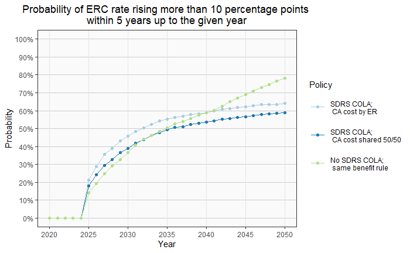

#### Risk of sharp EEC increase

This graph shows the probability that the EEC rate will rise by more than 5 percentage points within any 5-year period leading up to the current year. For example, in 2035 it shows the probability that the EEC rose by 5 percentage points or more in any prior 5-year period (2020-2024, 2021-2025, …, 2031-2035). This is designed to show whether the plan member was likely to face a sharp increase in contribution costs in a short period of time, during the period examined. Note that we use a 5 percentage point change for the EEC and a 10 percentage point change for the ERC, on the belief that individuals may consider a smaller sharp change to their take home pay to be quite significant.

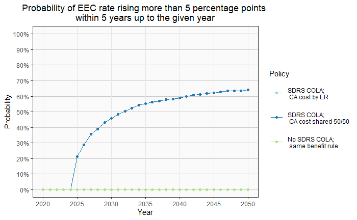

## 3.3 **Analysis of funded status**

### Risk of low funded ratio (cumulative)

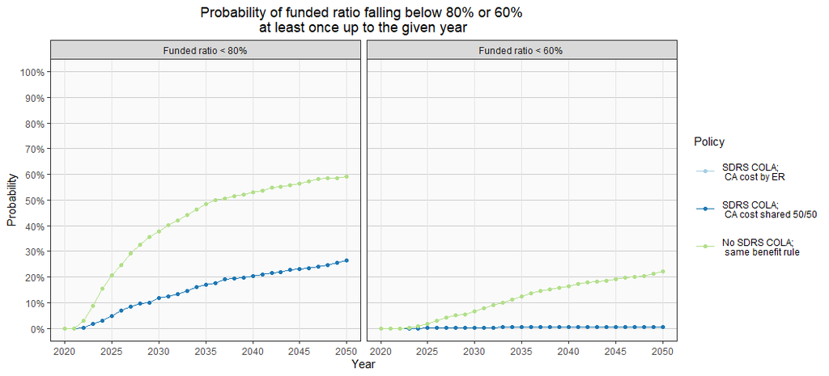

### Risk of low funded ratio (non-cumulative)

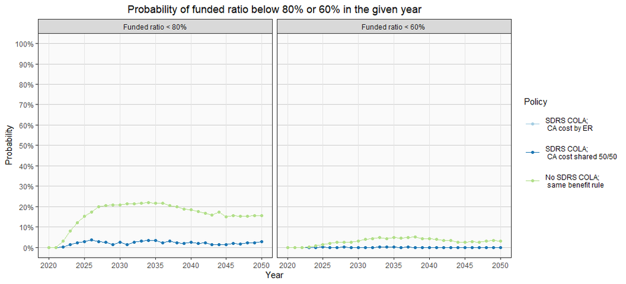

### Probability of full funding

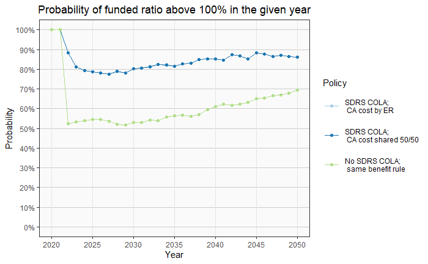

## 3.4 **Analysis of member benefit**

Cohort examined:

- Joined the plan at age 25 in 1986
- Start receiving benefit at age 60 in 2021
- live to age 90 (30 years in retirement)

### distribution of present value of benefit

Distribution of 30-year present value of benefit

For members who retire at age 60 with 35 years of service in 2021

| Policy | 90th | 75th | 50th | 25th | 10th |
| --- | --- | --- | --- | --- | --- |
| SDRS COLA; CA cost by ER | 1,767 | 1,757 | 1,701 | 1,639 | 1,598 |
| SDRS COLA; CA cost shared 50/50 | 1,767 | 1,757 | 1,701 | 1,639 | 1,598 |
| No SDRS COLA; same benefit rule | 1,767 | 1,767 | 1,767 | 1,767 | 1,767 |

Note: starting benefit is normalized to $100

### distribution of replacement rate at age 75

Distribution of replacement rate at age 75

For members who retire at age 60 with 35 years of service in 2021

| Policy | 90th | 75th | 50th | 25th | 10th |
| --- | --- | --- | --- | --- | --- |
| SDRS COLA; CA cost by ER | 0.65 | 0.65 | 0.62 | 0.58 | 0.56 |
| SDRS COLA; CA cost shared 50/50 | 0.65 | 0.65 | 0.62 | 0.58 | 0.56 |
| No SDRS COLA; same benefit rule | 0.65 | 0.65 | 0.65 | 0.65 | 0.65 |

Note: benefits at age 75 are adjusted for inflation; assumed inflation = 2.75%